# Project: Investigate a Dataset - [No Show Appointments]

- Introduction
- Data Wrangling
- Exploratory Data Analysis
- Conclusions

## Introduction

### Dataset Description

The dataset being studied is over 100,000 medical appointment records in Brazil, these statistics were taken in May 2016. The set focuses on wheather or not patients show up to appointments based on different criteria such as age, gender, medical condition, scholarship*, location of the hospital and wheather the patients were texted their appontment dates.

### Questions for Analysis

This report will explore the follwoing questions:

1. What is the correlation between texting patients'appointments and the number of no-shows?
2. Is there an age group/gender discrepancy of no-shows among those who have received sms'?
3. Is there a correlation between patients on scholarship and non attendance to appointments?
4. What are the no show means for patients with different medical conditions?

*Scholarship is the Brazilian welfare programme also known as Bolsa Familia in Brazil

```python
#==================
# IMPORT STATEMENTS
#==================

import numpy as np
import pandas as pd
import matplotlib.pyplot as plt
import seaborn as sns
%matplotlib inline
```

## Data Wrangling

In the section, I will do the following:

1. Read the data form the original CSV file and save it in a dataframe
2. Check the data for NAN values, duplicates, data types, and any other descrepancies in the data.

### General Properties

Data of interest to this report are:

1. Gender, object type presented as "F" and "M".
2. Age as int.
3. scholarship, health conditions and sms were presented as 0s and 1s for true and false.
4. No_show presented, object type presented as Yes and No

```python
# Loading data and displaying the first two lines of the set
df = pd.read_csv('noshowappointments-kagglev2-may-2016.csv')
df.head(2)
```

|  | PatientId | AppointmentID | Gender | ScheduledDay | AppointmentDay | Age | Neighbourhood | Scholarship | Hipertension | Diabetes | Alcoholism | Handcap | SMS_received | No-show |
| --- | --- | --- | --- | --- | --- | --- | --- | --- | --- | --- | --- | --- | --- | --- |
| 0 | 2.987250e+13 | 5642903 | F | 2016-04-29T18:38:08Z | 2016-04-29T00:00:00Z | 62 | JARDIM DA PENHA | 0 | 1 | 0 | 0 | 0 | 0 | No |
| 1 | 5.589978e+14 | 5642503 | M | 2016-04-29T16:08:27Z | 2016-04-29T00:00:00Z | 56 | JARDIM DA PENHA | 0 | 0 | 0 | 0 | 0 | 0 | No |

```python
# finding data types and null values, the data seems clean the only data type I may need to change is the no-show to bool type for convenience
df.info()
```

```
<class 'pandas.core.frame.DataFrame'>
RangeIndex: 110527 entries, 0 to 110526
Data columns (total 14 columns):
 #   Column          Non-Null Count   Dtype
---  ------          --------------   -----
 0   PatientId       110527 non-null  float64
 1   AppointmentID   110527 non-null  int64
 2   Gender          110527 non-null  object
 3   ScheduledDay    110527 non-null  object
 4   AppointmentDay  110527 non-null  object
 5   Age             110527 non-null  int64
 6   Neighbourhood   110527 non-null  object
 7   Scholarship     110527 non-null  int64
 8   Hipertension    110527 non-null  int64
 9   Diabetes        110527 non-null  int64
 10  Alcoholism      110527 non-null  int64
 11  Handcap         110527 non-null  int64
 12  SMS_received    110527 non-null  int64
 13  No-show         110527 non-null  object
dtypes: float64(1), int64(8), object(5)
memory usage: 11.8+ MB
```

```python
# Finding more information about the data
df.drop(['PatientId', 'AppointmentID'], axis=1).describe()
```

|  | Age | Scholarship | Hipertension | Diabetes | Alcoholism | Handcap | SMS_received |
| --- | --- | --- | --- | --- | --- | --- | --- |
| count | 110527.000000 | 110527.000000 | 110527.000000 | 110527.000000 | 110527.000000 | 110527.000000 | 110527.000000 |
| mean | 37.088874 | 0.098266 | 0.197246 | 0.071865 | 0.030400 | 0.022248 | 0.321026 |
| std | 23.110205 | 0.297675 | 0.397921 | 0.258265 | 0.171686 | 0.161543 | 0.466873 |
| min | -1.000000 | 0.000000 | 0.000000 | 0.000000 | 0.000000 | 0.000000 | 0.000000 |
| 25% | 18.000000 | 0.000000 | 0.000000 | 0.000000 | 0.000000 | 0.000000 | 0.000000 |
| 50% | 37.000000 | 0.000000 | 0.000000 | 0.000000 | 0.000000 | 0.000000 | 0.000000 |
| 75% | 55.000000 | 0.000000 | 0.000000 | 0.000000 | 0.000000 | 0.000000 | 1.000000 |
| max | 115.000000 | 1.000000 | 1.000000 | 1.000000 | 1.000000 | 4.000000 | 1.000000 |

```python
# The min age is -1 so looking further into this
df.loc[df['Age'] == -1]
```

|  | PatientId | AppointmentID | Gender | ScheduledDay | AppointmentDay | Age | Neighbourhood | Scholarship | Hipertension | Diabetes | Alcoholism | Handcap | SMS_received | No-show |
| --- | --- | --- | --- | --- | --- | --- | --- | --- | --- | --- | --- | --- | --- | --- |
| 99832 | 4.659432e+14 | 5775010 | F | 2016-06-06T08:58:13Z | 2016-06-06T00:00:00Z | -1 | ROMÃO | 0 | 0 | 0 | 0 | 0 | 0 | No |

```python
# According to original data handcap should be true or false
df.loc[df['Handcap'] > 1].head()
```

|  | PatientId | AppointmentID | Gender | ScheduledDay | AppointmentDay | Age | Neighbourhood | Scholarship | Hipertension | Diabetes | Alcoholism | Handcap | SMS_received | No-show |
| --- | --- | --- | --- | --- | --- | --- | --- | --- | --- | --- | --- | --- | --- | --- |
| 946 | 7.282582e+13 | 5582483 | M | 2016-04-14T09:26:08Z | 2016-04-29T00:00:00Z | 94 | BELA VISTA | 0 | 1 | 1 | 0 | 2 | 1 | No |
| 1665 | 1.242919e+13 | 5525497 | M | 2016-03-30T09:16:41Z | 2016-04-29T00:00:00Z | 64 | SANTA MARTHA | 0 | 1 | 0 | 1 | 2 | 1 | No |
| 1666 | 1.242919e+13 | 5525498 | M | 2016-03-30T09:16:41Z | 2016-04-29T00:00:00Z | 64 | SANTA MARTHA | 0 | 1 | 0 | 1 | 2 | 0 | No |
| 2071 | 1.242919e+13 | 5640120 | M | 2016-04-29T10:08:48Z | 2016-04-29T00:00:00Z | 64 | SANTA MARTHA | 0 | 1 | 0 | 1 | 2 | 0 | No |
| 2091 | 1.491829e+13 | 5638626 | F | 2016-04-29T08:13:59Z | 2016-04-29T00:00:00Z | 11 | ANDORINHAS | 0 | 0 | 0 | 0 | 2 | 0 | No |

```python
#cheking for duplicates
df.duplicated().sum()
```

```
0
```

### Data Cleaning

Based on the raw data analysis, the following changes will be made:

a) The columns that will not be used in the report will be dropped.

```
The dropped columns will be:
1. PatientId.
2. AppointmentID.
3. ScheduledDay.
4. AppointmentDay.
5. Neighbourhood.
```

b) The column names will be converted to be all lower case for ease.

c) The columns that will be renamed:

```
1. 'hipertension' to 'hypertension' Due to misspelling.
2. 'handcap' to 'disability' To use the correct medical term.
3. 'no-show' to 'no_show' To make the column names consistant.
```

d) The patient with age == -1 will be dropped as there is only one patient with that mistake so dropping will not be significant to final outcome.

e) The disability column with values more than 1 will be changed to 1, because according to the original source, this column should be either true or false.

f) The no show data type will be changed to int type, 0 for the patients who showed up and 1 for no show.

```python
#=============
# DATA CLEANUP
#=============

# Dropping unnecessary columns
df_mod = df.drop(['PatientId',  'AppointmentID', 'ScheduledDay', 'AppointmentDay', 'Neighbourhood'], axis = 1)

# Lowering the case of the columns
df_mod = df_mod.rename(columns= str.lower)

# Renaming columns
df_mod = df_mod.rename(columns = {'hipertension':'hypertension', 'handcap':'disability', 'no-show':'no_show'})
```

```python
# displaying the dataframe
df_mod.head(2)
```

|  | gender | age | scholarship | hypertension | diabetes | alcoholism | disability | sms_received | no_show |
| --- | --- | --- | --- | --- | --- | --- | --- | --- | --- |
| 0 | F | 62 | 0 | 1 | 0 | 0 | 0 | 0 | No |
| 1 | M | 56 | 0 | 0 | 0 | 0 | 0 | 0 | No |

```python
# Checking the shape of the dataframe
df_mod.shape
```

```
(110527, 9)
```

```python
# Making sure that all the data in the no-show column is lower case
df_mod['no_show'] = df_mod['no_show'].str.lower()

# changing the data type in the no-show column to int
df_mod['no_show'] = df_mod['no_show'].map({'yes':1, 'no':0})

# Checking the datatypes
df_mod.info()
```

```
<class 'pandas.core.frame.DataFrame'>
RangeIndex: 110527 entries, 0 to 110526
Data columns (total 9 columns):
 #   Column        Non-Null Count   Dtype
---  ------        --------------   -----
 0   gender        110527 non-null  object
 1   age           110527 non-null  int64
 2   scholarship   110527 non-null  int64
 3   hypertension  110527 non-null  int64
 4   diabetes      110527 non-null  int64
 5   alcoholism    110527 non-null  int64
 6   disability    110527 non-null  int64
 7   sms_received  110527 non-null  int64
 8   no_show       110527 non-null  int64
dtypes: int64(8), object(1)
memory usage: 7.6+ MB
```

```python
# Dropping the patient whose age is -1
df_mod = df_mod.drop(df_mod[df_mod['age']== -1].index)

# checking the age column
df_mod.loc[df_mod['age'] < 0]
```

|  | gender | age | scholarship | hypertension | diabetes | alcoholism | disability | sms_received | no_show |
| --- | --- | --- | --- | --- | --- | --- | --- | --- | --- |

```python
# Fixing the disability column
df_mod.loc[df_mod['disability']>1 , 'disability']=1

# checking the disability column
df_mod.loc[df_mod['disability'] > 1]
```

|  | gender | age | scholarship | hypertension | diabetes | alcoholism | disability | sms_received | no_show |
| --- | --- | --- | --- | --- | --- | --- | --- | --- | --- |

```python
# final detail check
df_mod.describe()
```

|  | age | scholarship | hypertension | diabetes | alcoholism | disability | sms_received | no_show |
| --- | --- | --- | --- | --- | --- | --- | --- | --- |
| count | 110526.000000 | 110526.000000 | 110526.000000 | 110526.000000 | 110526.000000 | 110526.000000 | 110526.000000 | 110526.000000 |
| mean | 37.089219 | 0.098266 | 0.197248 | 0.071865 | 0.030400 | 0.020276 | 0.321029 | 0.201934 |
| std | 23.110026 | 0.297676 | 0.397923 | 0.258266 | 0.171686 | 0.140943 | 0.466874 | 0.401445 |
| min | 0.000000 | 0.000000 | 0.000000 | 0.000000 | 0.000000 | 0.000000 | 0.000000 | 0.000000 |
| 25% | 18.000000 | 0.000000 | 0.000000 | 0.000000 | 0.000000 | 0.000000 | 0.000000 | 0.000000 |
| 50% | 37.000000 | 0.000000 | 0.000000 | 0.000000 | 0.000000 | 0.000000 | 0.000000 | 0.000000 |
| 75% | 55.000000 | 0.000000 | 0.000000 | 0.000000 | 0.000000 | 0.000000 | 1.000000 | 0.000000 |
| max | 115.000000 | 1.000000 | 1.000000 | 1.000000 | 1.000000 | 1.000000 | 1.000000 | 1.000000 |

## Exploratory Data Analysis

### Research Question 1: What is the correlation between texting patients' appointments to the number of no-shows?

```python
# Mean of people who were texted their appointments
df_mod['sms_received'].mean()
```

```
0.3210285362720084
```

The calculations below shows that among the people who were texted their appointments, the people who attended their appointments are more than those who didn't.

```python
# Number of people who were texted and showed up vs no shows
df_mod.groupby('sms_received')['no_show'].sum()
```

```
sms_received
0    12535
1     9784
Name: no_show, dtype: int64
```

This result however is inconclusive because on averageو more people show up to their appointments regardless of them being sent texts as shown in the figure below. In fact the percentage of no shows appears to be higher among those who received an sms.

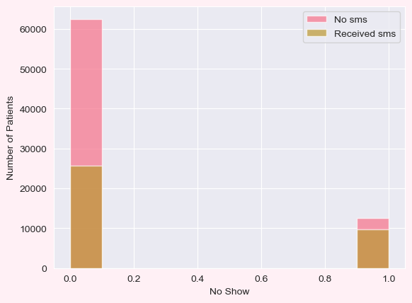

```python
#plotting the correlation
plt.figure(facecolor = 'lavenderblush')
sns.set_palette('husl')
sns.set_style('darkgrid')
df_mod.groupby('sms_received')['no_show'].hist( alpha = 0.7,legend = True)
plt.xlabel('No Show')
plt.ylabel('Number of Patients')
plt.legend(['No sms','Received sms']);
```

This result can be confirmed further via the following calculations; there is an increase by 0.1 in no show means.

```python
#finding the means of no shows of people who have received sms and those who didn't
df_mod.groupby('sms_received')['no_show'].mean()
```

```
sms_received
0    0.167035
1    0.275745
Name: no_show, dtype: float64
```

### Research Question 2: Is there an age group/gender discrepancy of no-shows among those who have received sms'?

```python
#filtering by sms received = 1 (this filtering results in an array)
fl = np.where((df_mod['sms_received'] == 1))
df_mod.loc[fl].head(2)
```

|  | gender | age | scholarship | hypertension | diabetes | alcoholism | disability | sms_received | no_show |
| --- | --- | --- | --- | --- | --- | --- | --- | --- | --- |
| 11 | M | 29 | 0 | 0 | 0 | 0 | 0 | 1 | 1 |
| 15 | F | 15 | 0 | 0 | 0 | 0 | 0 | 1 | 0 |

Next, calculating the mean of each gender's no shows then plotting the result. As can be seen form the pie chart below, both genders skipped their appointments nearly equally.

```python
# Finding the means of no shows by gender using the sms filter
df_mod.loc[fl].groupby('gender')['no_show'].mean()
```

```
gender
F    0.270525
M    0.265143
Name: no_show, dtype: float64
```

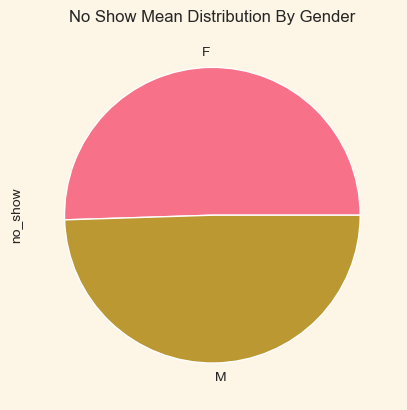

```python
#plotting the relation
plt.figure(facecolor = 'oldlace')
sns.set_palette('husl')
df_mod.loc[fl].groupby('gender')['no_show'].mean().plot(kind = 'pie', title = 'no show mean distribution by gender'.title());
```

The next pie chart is the division in terms of age groups. Firstly, the ages groups need to be put into bins as follows.

```python
#dividing the different age groups into bins
age_groups = [0, 18, 35, 60, 80, 115]
df_mod['age_group'] = pd.cut(df_mod.age, age_groups)
```

The the mean can be calculated and the resulting pie chart is shown below. the results of patients in the first two age groups (0-18) and (18-35) are similar with both being the first and second highset groups of no shows. wheras people between 60-80 are the lease likely to skip appointments,

```python
#calculating the means of no show based on agegroup
df_mod.loc[fl].groupby('age_group')['no_show'].mean()
```

```
age_group
(0, 18]      0.305071
(18, 35]     0.332400
(35, 60]     0.247742
(60, 80]     0.187016
(80, 115]    0.200798
Name: no_show, dtype: float64
```

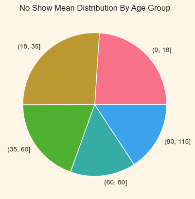

```python
#Plotting by age group
plt.figure(facecolor = 'oldlace')
sns.set_palette('husl')
df_mod.loc[fl].groupby('age_group')['no_show'].mean().plot(kind = 'pie', title = 'no show mean distribution by age group'.title(), label = '');
```

### Research Question 3: Is there a correlation between patients on scholarship and non attendance to appointments?

To answer this question, we need to compare no shows in both patients who have received scolarships and those who have not.

```python
#finding so show means based on scholarship or no scholarship
df_mod.groupby('scholarship')['no_show'].mean()
```

```
scholarship
0    0.198074
1    0.237363
Name: no_show, dtype: float64
```

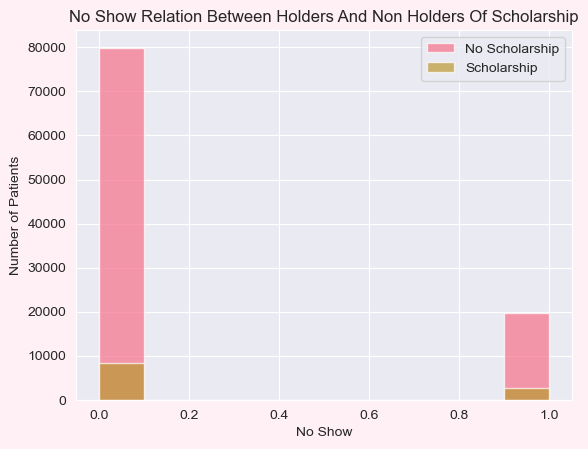

```python
#plotting relations
plt.figure(facecolor = 'lavenderblush')
sns.set_palette('husl')
sns.set_style('darkgrid')
df_mod.groupby('scholarship')['no_show'].hist(alpha = 0.7, legend = True)
plt.title('no show relation between holders and non holders of scholarship'.title())
plt.xlabel('No Show')
plt.ylabel('Number of Patients')
plt.legend(['No Scholarship','Scholarship']);
```

As shown from the calculation and graph above, there is a slight difference between no show rates between holders and non holders of scholarships, but the difference is too small to say there is a correlation.

### Research Question 4: What are the no show means for patients with different medical conditions?

The plot below shows the means of the different medical conditions.

```python
#finding the means of the different medical conditons with a no show=1 filter
fl2 = df_mod['no_show'] == 1
mc = df_mod[fl2].iloc[:,3:7].mean()
mc
```

```
hypertension    0.169004
diabetes        0.064071
alcoholism      0.030333
disability      0.018236
dtype: float64
```

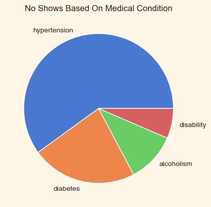

```python
#plotting the chart and setting the theme
plt.figure(facecolor = 'oldlace')
sns.set_palette('muted')
mc.plot(kind='pie')
plt.title('no shows based on medical condition'.title());
```

## Conclusions

In conclusion, in this study, there seems to be a positive correlation between sending patients sms' about their appontments and no show rates, there doesn't seem to be a descrepancy in no shows in terms gender however, there are on average more younger people between the ages of 0-35 who skip thier appointments when they are texted.

The results above are tentative, due to the time frame being only one month, additionalyy, in comparison to the population of brazil, this sample seems to be too small. The methods of finding data in this report is limited and more advanced statistical technology needs to be used in order to get better estimates.

Further questions that can be asked are if there is a difference in attendance in different times of day, days of week or even months of year and reasonings for the discrepancy needs to be explored. Another question is patient experience and proximity to hospitals which could affect no shows. Hence, more data on patient satisfaction is needed. Finally the data given does not specify if these appointments are followups that can be switched to remote appointments or essencial appointmens that requires patients to attend.

## Resources

https://www.kaggle.com/datasets/joniarroba/noshowappointments https://matplotlib.org/cheatsheets/ https://saturncloud.io/blog/visualizing-data-with-seaborn-plotting-pandas-dataframe-by-multiple-groupby/ https://stackoverflow.com/questions/36909977/update-row-values-where-certain-condition-is-met-in-pandas https://kanoki.org/how-to-prevent-xticks-overlapping-in-matplotlib#:~:text=Increase%20figure%20size%20-%20figsize,figsize%20the%20graph%20looks%20better.